# ISA 401: Business Intelligence & Data Visualization

## 08: Structured Data from APIs

### <br>Fadel M. Megahed, PhD <br><br> Raymond E. Glos Professor in Business <br> Farmer School of Business<br> Miami University<br><br> <a href="https://www.linkedin.com/in/fadel-megahed-289046b4"><svg viewBox="0 0 448 512" style="height:1em;display:inline-block;vertical-align:-.1em;fill:white;" xmlns="http://www.w3.org/2000/svg"> <path d="M416 32H31.9C14.3 32 0 46.5 0 64.3v383.4C0 465.5 14.3 480 31.9 480H416c17.6 0 32-14.5 32-32.3V64.3c0-17.8-14.4-32.3-32-32.3zM135.4 416H69V202.2h66.5V416zm-33.2-243c-21.3 0-38.5-17.3-38.5-38.5S80.9 96 102.2 96c21.2 0 38.5 17.3 38.5 38.5 0 21.3-17.2 38.5-38.5 38.5zm282.1 243h-66.4V312c0-24.8-.5-56.7-34.5-56.7-34.6 0-39.9 27-39.9 54.9V416h-66.4V202.2h63.7v29.2h.9c8.9-16.8 30.6-34.5 62.9-34.5 67.2 0 79.7 44.3 79.7 101.9V416z" /></svg> <span class="citation">@Fadel</span> Megahed</a> <br> <a href="https://github.com/fmegahed/"><svg viewBox="0 0 496 512" style="height:1em;display:inline-block;vertical-align:-.1em;fill:white;" xmlns="http://www.w3.org/2000/svg"> <path d="M165.9 397.4c0 2-2.3 3.6-5.2 3.6-3.3.3-5.6-1.3-5.6-3.6 0-2 2.3-3.6 5.2-3.6 3-.3 5.6 1.3 5.6 3.6zm-31.1-4.5c-.7 2 1.3 4.3 4.3 4.9 2.6 1 5.6 0 6.2-2s-1.3-4.3-4.3-5.2c-2.6-.7-5.5.3-6.2 2.3zm44.2-1.7c-2.9.7-4.9 2.6-4.6 4.9.3 2 2.9 3.3 5.9 2.6 2.9-.7 4.9-2.6 4.6-4.6-.3-1.9-3-3.2-5.9-2.9zM244.8 8C106.1 8 0 113.3 0 252c0 110.9 69.8 205.8 169.5 239.2 12.8 2.3 17.3-5.6 17.3-12.1 0-6.2-.3-40.4-.3-61.4 0 0-70 15-84.7-29.8 0 0-11.4-29.1-27.8-36.6 0 0-22.9-15.7 1.6-15.4 0 0 24.9 2 38.6 25.8 21.9 38.6 58.6 27.5 72.9 20.9 2.3-16 8.8-27.1 16-33.7-55.9-6.2-112.3-14.3-112.3-110.5 0-27.5 7.6-41.3 23.6-58.9-2.6-6.5-11.1-33.3 2.6-67.9 20.9-6.5 69 27 69 27 20-5.6 41.5-8.5 62.8-8.5s42.8 2.9 62.8 8.5c0 0 48.1-33.6 69-27 13.7 34.7 5.2 61.4 2.6 67.9 16 17.7 25.8 31.5 25.8 58.9 0 96.5-58.9 104.2-114.8 110.5 9.2 7.9 17 22.9 17 46.4 0 33.7-.3 75.4-.3 83.6 0 6.5 4.6 14.4 17.3 12.1C428.2 457.8 496 362.9 496 252 496 113.3 383.5 8 244.8 8zM97.2 352.9c-1.3 1-1 3.3.7 5.2 1.6 1.6 3.9 2.3 5.2 1 1.3-1 1-3.3-.7-5.2-1.6-1.6-3.9-2.3-5.2-1zm-10.8-8.1c-.7 1.3.3 2.9 2.3 3.9 1.6 1 3.6.7 4.3-.7.7-1.3-.3-2.9-2.3-3.9-2-.6-3.6-.3-4.3.7zm32.4 35.6c-1.6 1.3-1 4.3 1.3 6.2 2.3 2.3 5.2 2.6 6.5 1 1.3-1.3.7-4.3-1.3-6.2-2.2-2.3-5.2-2.6-6.5-1zm-11.4-14.7c-1.6 1-1.6 3.6 0 5.9 1.6 2.3 4.3 3.3 5.6 2.3 1.6-1.3 1.6-3.9 0-6.2-1.4-2.3-4-3.3-5.6-2z" /></svg> fmegahed</a> <br> <a href="mailto:fmegahed@miamioh.edu"><svg viewBox="0 0 512 512" style="height:1em;display:inline-block;vertical-align:-.1em;fill:white;" xmlns="http://www.w3.org/2000/svg"> <path d="M476 3.2L12.5 270.6c-18.1 10.4-15.8 35.6 2.2 43.2L121 358.4l287.3-253.2c5.5-4.9 13.3 2.6 8.6 8.3L176 407v80.5c0 23.6 28.5 32.9 42.5 15.8L282 426l124.6 52.2c14.2 6 30.4-2.9 33-18.2l72-432C515 7.8 493.3-6.8 476 3.2z" /></svg> fmegahed@miamioh.edu</a><br> <a href="https://calendly.com/fmegahed"><svg viewBox="0 0 384 512" style="height:1em;display:inline-block;vertical-align:-.1em;fill:white;" xmlns="http://www.w3.org/2000/svg"> <path d="M202.021 0C122.202 0 70.503 32.703 29.914 91.026c-7.363 10.58-5.093 25.086 5.178 32.874l43.138 32.709c10.373 7.865 25.132 6.026 33.253-4.148 25.049-31.381 43.63-49.449 82.757-49.449 30.764 0 68.816 19.799 68.816 49.631 0 22.552-18.617 34.134-48.993 51.164-35.423 19.86-82.299 44.576-82.299 106.405V320c0 13.255 10.745 24 24 24h72.471c13.255 0 24-10.745 24-24v-5.773c0-42.86 125.268-44.645 125.268-160.627C377.504 66.256 286.902 0 202.021 0zM192 373.459c-38.196 0-69.271 31.075-69.271 69.271 0 38.195 31.075 69.27 69.271 69.27s69.271-31.075 69.271-69.271-31.075-69.27-69.271-69.27z" /></svg> Automated Scheduler for Office Hours</a><br><br>

### Fall 2026

# Before We Start

1 Join today's Zoom

Use the Zoom link in the [**Week 0 Module**](https://miamioh.instructure.com/courses/258169/modules/981092) on Canvas. **Mute** your mic and **turn off** your video.  
Log in from the lab's computer so you can share your screen if you need help with an error.

2 Open the project, start the markdown

**GitHub Desktop** → `business_intelligence` → **Fetch origin**, then open `business_intelligence.Rproj`.  
New R Markdown, title *Class 08*, delete everything below the setup chunk, save as markdowns/class08.Rmd.

3 Install one package

In the **Console** (not in the markdown): `install.packages("httr2")`  
`jsonlite` and `dplyr` are already installed from Classes 04 and 07.

4 Request your USAJOBS key now

Fill the form at [**developer.usajobs.gov/apirequest**](https://developer.usajobs.gov/apirequest/) with your Miami email, then confirm the email they send.  
The key arrives in a later email. We use it in Part 3, about 30 minutes from now.

Done early? **Help the person next to you.** Stuck? **Share your screen on Zoom** and we fix it together.

# Where We Left Off

Class 04: "a web-served JSON file"

```
crashes = jsonlite::fromJSON(  "https://data.cincinnati-oh.gov/resource/rvmt-pkmq.json?$limit=100")
```

We pasted an address and got 100 rows. We did not discuss the `?$limit=100` at the end of it.

Today: the same address is an API

```
crashes = httr2::request("https://data.cincinnati-oh.gov/resource/rvmt-pkmq.json") |>  httr2::req_url_query("$limit" = 100) |>  httr2::req_perform() |>  httr2::resp_body_string() |>  jsonlite::fromJSON()
```

Everything after the `?` is a set of query parameters. Today you write them yourself.

**Both return the same 100 rows.** We use the `httr2` version today because it can also send a key, send headers, and report the status code. `jsonlite::fromJSON()` on an address cannot.

# Learning Objectives for Today's Class

- **Define** what an API is and why APIs matter for data analysts.
- **Construct** API requests and handle authentication.
- **Parse** JSON responses into data frames.

Part 1 14 min

**What is an API?** The steps of a request, shown on Cincinnati's crash data (no key). The parts of an API URL. Status codes. The Class 06 chat app as an API client.

Part 2 15 min

**One key in the URL.** FRED: get a key, store it in `.Renviron`, read the documentation, request Ohio job postings.

Part 3 25 min

**Key in headers.** USAJOBS: reading documentation, nested JSON to a data frame, federal Data Analyst jobs. Then the same pipeline calls OpenAI.

**The same httr2 pipeline is used in every part.** Each API adds one line to it: query parameters, then a key, then headers, then a body. The Cincinnati request is worked out in full in Appendix A1 and A2.

# Part 1: What Is an API?

# What Is an API?

Client

**Your R session.** It wants data it does not have: crash reports, a job postings index, federal job ads.

→

API: application programming interface

**The documented contract between the two.** Which requests you may send, how to write them, and what comes back. Written for programs, not for people clicking.

→

Server

**Someone else's computer** holding the data. It answers requests that follow the contract and refuses the rest.

**The interface is separate from the implementation.** The owner can change the database behind the API. If the documented requests and replies stay the same, your code keeps working.

**Controlled by the owner.** The API exposes only what the owner chooses, to whom they choose, at the rate they choose. That is what keys and limits are for.

**First example:** the City of Cincinnati's crash data from Class 04. The next slides use it to show where an API address comes from and what happens when R sends a request.

Definition adapted from the [MDN Web Docs glossary entry for API](https://developer.mozilla.org/en-US/docs/Glossary/API).

# Documentation: Cincinnati Crash Data

[figure not shown]

What this page tells us

1On the dataset's page, **Actions** then **API** opens this dialog.

2The table has **433,160 rows**. Too many to download for one question.

3One request returns **1,000 rows** unless we ask for a different number.

4Two API versions. **SODA3** requires authentication. **SODA2** does not, so we use it today.

5The **API endpoint**: the address that every request to this table starts with.

6The link to the **API documentation**, which lists the column names and the query options.

Open it yourself: [Traffic Crash Reports (CPD)](https://data.cincinnati-oh.gov/safety/Traffic-Crash-Reports-CPD-/rvmt-pkmq) on the City of Cincinnati open data portal, then **Actions**, then **API**. Screenshot taken Sep 21, 2026.

The portal notes that this dataset is paused while the city changes record systems. The newest record is dated Aug 24, 2026.

# A Request, Step by Step: Cincinnati

GEThttps://data.cincinnati-oh.gov/resource/rvmt-pkmq.json?$limit=5

Your R session

httr2 builds and sends the request

data.cincinnati-oh.gov

checks the request, finds the rows

```
httr2::request("https://data.cincinnati-oh.gov/resource/rvmt-pkmq.json") |>  httr2::req_url_query("$limit" = 5) |>  httr2::req_perform() |>  httr2::resp_body_string() |>  jsonlite::fromJSON()
```

A data frame: 5 rows, 27 columns (three shown)

| crashdate | crashseverity | age |
| --- | --- | --- |
| 2026-08-23T14:00 | 2 - SERIOUS INJURY SUS | 27 |
| 2026-08-23T14:00 | 2 - SERIOUS INJURY SUS | 24 |
| 2026-08-23T13:57 | 5 - PROPERTY DAMAGE ON | NA |
| 2026-08-23T13:53 | 5 - PROPERTY DAMAGE ON | 18 |
| 2026-08-23T13:53 | 5 - PROPERTY DAMAGE ON | 37 |

**Start.** Your R session wants crash records. They live on a server run by the City of Cincinnati.

**The address.** Blue is the server. Green is the path to one dataset on it. Both come from the API documentation.

**The query parameters.** After the **?** come **name=value** pairs that the documentation defines. `$limit=5` asks for five rows.

**Send.** `req_perform()` is the only line that touches the network. Everything before it only wrote the request.

**The server processes the request.** It checks that the request is valid, then looks up five rows.

**The reply.** A status code first (**200** means OK), then the data as JSON text.

**Parse.** `jsonlite::fromJSON()` turns the JSON text into a data frame. The dplyr verbs from Class 07 apply from here.

0 / 6

... (shortened: 5 records, 27 fields each)[
  {
    "crashdate": "2026-08-23T14:00:00.000",
    "crashseverity": "2 - SERIOUS INJURY SUSPECTED",
    "age": "27"
  },
  {
    "crashdate": "2026-08-23T14:00:00.000",
    "crashseverity": "2 - SERIOUS INJURY SUSPECTED",
    "age": "24"
  }

... (shortened: 5 records, 27 fields each)

# Anatomy of an API URL

https://data.cincinnati-oh.gov/resource/rvmt-pkmq.json?$limit=5&$order=crashdate DESC

**Server**  
Whose computer. The City of Cincinnati's open data site.

**Path (endpoint)**  
Which dataset on that server. `rvmt-pkmq` is the traffic crash table; `.json` is the format.

**? and &**  
**?** starts the question. **&** separates one parameter from the next.

**name=value**  
Query parameters. Each API defines its own parameter names and lists them in its documentation.

**This server's parameters:** `$limit` how many rows, `$order` sorted how, `$where` which rows, `$select` which columns. They correspond to the SQL clauses from Class 06 and the dplyr verbs from Class 07, and Socrata documents each one ([LIMIT](https://dev.socrata.com/docs/queries/limit.html), [ORDER BY](https://dev.socrata.com/docs/queries/order.html), [WHERE](https://dev.socrata.com/docs/queries/where.html), [SELECT](https://dev.socrata.com/docs/queries/select.html)). **The $ is part of the name on this server:** a request with `limit=5` is answered with 400, "Unrecognized arguments [limit]".

# Status Codes

**200** **OK**  
The request was understood and the data is in the body.

**400** **Bad Request**  
The server could not read your request: a misspelled or missing parameter.

**401 / 403** **Unauthorized / Forbidden**  
The server does not know who you are, or knows and says no. Usually the key.

**404** **Not Found**  
Nothing lives at that path. Check the address against the documentation.

**429** **Too Many Requests**  
You passed the owner's rate limit. Wait, then ask less often.

**500s** **Server errors**  
The problem is on their side. Your request may be fine; try again later.

**Read the first digit:** 2 means success, 4 means a problem with your request, 5 means a problem on the server. `httr2::req_perform()` stops with an R error on any 4xx or 5xx reply, and the error message starts with the code. Meanings from the [MDN HTTP status code reference](https://developer.mozilla.org/en-US/docs/Web/HTTP/Reference/Status).

# Three Uses of the Word API

1 Data from a web server

A request over the internet, a reply in JSON. **Today's topic.**

The Cincinnati request you just saw. Next: FRED economic series and USAJOBS postings.

2 A package's functions

The documented functions of a package are its API: names, arguments, and what each returns.

You used one last week: the [dplyr function reference](https://dplyr.tidyverse.org/reference/index.html). No network involved.

3 A model behind a server

You send text, a model on someone else's computer sends text back. Same request and reply as use 1.

The Class 06 chat app works this way. See the next slide.

**What the three share:** documentation that says what you may ask for and what you get back, so you never need to see how the other side is built.

# Your Chat App Is an API Client

You askThe app sends a requestThe model writes SQLThe app runs the SQLThe key

Job Scout Chat, in your browser

Which states have the most remote postings?

What you saw in Class 06

A question typed in plain English, and a table a few seconds later.

`app.R` is a short R script with no language model inside it. Something else interprets the question.

The request the app sends

POST https://api.openai.com/...

Authorization: Bearer ••••OPENAI_API_KEY

Body: the model name (`gpt-5.6-luna` in our `app.R`), your question, and instructions from querychat

What goes to the model, in querychat's words

"querychat **does not** send raw data to the LLM; it shares only enough structural information for the model to generate accurate queries."

For our table that means its 19 column names, their types, ranges, and categories. Source: [querychat for R, How it works](https://posit-dev.github.io/querychat/r/).

The reply contains SQL

**SELECT** location_state, **COUNT**(*) **AS** n **FROM** scout_postings **WHERE** remote = 1 **AND** location_state **IS NOT NULL** **GROUP BY** location_state **ORDER BY** n **DESC** **LIMIT** 5

What the model did

"querychat uses LLMs to translate natural language into SQL queries." The reply is a status code and JSON, like every reply today; the SQL is a string inside it.

This query is an example written for this slide; the model's wording varies from run to run.

The app runs the SQL on its own copy of the data

| location_state | n |
| --- | --- |
| TX | 25 |
| OH | 18 |
| NY | 16 |
| CA | 15 |
| NC | 13 |

Where the numbers come from

"When the LLM produces a query, querychat executes it in a SQL database (DuckDB, by default) to obtain precise results."

The table on the left is that query run on `scout.db` when these slides were built. The model wrote the SQL. The database computed the result.

The request the app sends

POST https://api.openai.com/...

Authorization: Bearer ••••OPENAI_API_KEY

Body: the model name, your question, and instructions from querychat

Sep 14: this is the value that leaked

The key identifies the account that sent the request and that is billed for it. Anyone who has the key can send requests on that account, which is why OpenAI disabled ours the day it appeared on GitHub.

OpenAI's own guidance: [Best practices for API key safety](https://help.openai.com/en/articles/5112595-best-practices-for-api-key-safety). In Part 3 you send this request yourself.

**You ask.** A question in English goes into the app you ran and deployed last week.

**An API call.** The app sends a request to OpenAI's server: an address, a header carrying the key, and a body carrying the question.

**The model returns SQL,** not numbers. It does not compute the counts.

**The app runs that SQL** in a database on its own side and shows you the result.

**Every question you typed was one of these requests,** and every one carried the key in a header.

0 / 4

# Part 2: One Key in the URL

# Get a FRED API Key

<countdown-timer class="countdown" id="timer_7a9d21e2" minutes="3" seconds="0" update-every="1" tabindex="0" style="top:0;right:0;--countdown-font-size:2em;"></countdown-timer>

1 Create a free account

Go to [**fredaccount.stlouisfed.org/apikeys**](https://fredaccount.stlouisfed.org/apikeys). It sends you to the sign-in page; create a free account with your Miami email.

2 Request the key

On the **API Keys** page click **Request API Key**. The form asks why you want it: *"Coursework for ISA 401 at Miami University"* is a complete answer.

3 Leave the page open

The key is 32 letters and digits, shown on the page right away. **Do not paste it into your markdown.** The next slide says where it goes.

**Why a key at all?** FRED's data is free, but the key tells the St. Louis Fed who is asking, so it can limit how fast any one person asks and switch off a key that misbehaves. Details: [FRED API Keys documentation](https://fred.stlouisfed.org/docs/api/api_key.html).

# Keep the Key Out of Your Code

**1.** In the **Console**, open the project's `.Renviron` file:

```
usethis::edit_r_environment("project")
```

**2.** Add one line, no quotes, no spaces, then save. (This is a made-up key.)

```
FRED_API_KEY=abcdefghijklmnopqrstuvwxyz123456
```

**3.** **Session → Restart R**. R reads `.Renviron` only when it starts.

**4.** Check it, and make sure Git ignores the file:

```
Sys.getenv("FRED_API_KEY")   # shows the key, so: Console onlyusethis::use_git_ignore(".Renviron")
```

Key typed in class08.Rmd

`class08.Rmd` → commit → push → **public on GitHub**, along with the key. This is what happened to the class OpenAI key on Sep 14.

Key in .Renviron

`class08.Rmd` says only `Sys.getenv("FRED_API_KEY")`. The value stays in `.Renviron`, which `.gitignore` keeps out of every commit. **The code is public, the key is not.**

Same recipe as the OpenAI key in [Class 07](http://fmegahed.github.io/isa401/fall2026/class07/07_data_wrangling.html). You will add a second line for USAJOBS in Part 3.

# Documentation: FRED

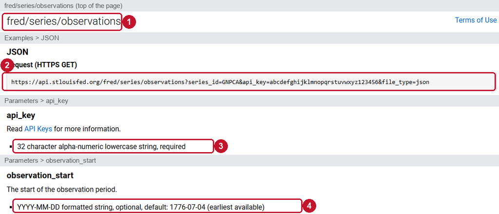

What this page tells us

1The **path** for the values of one series: `fred/series/observations`.

2An **example request**. Server, path, then three parameters: `series_id`, `api_key`, `file_type`. The key shown is a made-up example.

3`api_key` is **required**, and it is a query parameter. That is where our key goes.

4`observation_start` is **optional**: a date as `YYYY-MM-DD`. Without it we get the whole history.

The full page: [fred/series/observations](https://fred.stlouisfed.org/docs/api/fred/series_observations.html) in the FRED API documentation. Four parts of one long page are shown. Screenshot taken Sep 21, 2026.

# A Request, Step by Step: FRED

GEThttps://api.stlouisfed.org/fred/series/observations?series_id=IHLIDXUSOH&file_type=json&api_key••••from .Renviron

Your R session

httr2 builds and sends the request

api.stlouisfed.org

checks the key, then finds the series

```
httr2::request("https://api.stlouisfed.org/fred/series/observations") |>  httr2::req_url_query(    series_id = "IHLIDXUSOH",    api_key = Sys.getenv("FRED_API_KEY"),    file_type = "json"  ) |>  # nothing has been sent yet  httr2::req_perform() |>  httr2::resp_body_string() |>  jsonlite::fromJSON()
```

| date | value |
| --- | --- |
| 2026-09-08 | 107.27 |
| 2026-09-09 | 107.28 |
| 2026-09-10 | 107.43 |
| 2026-09-11 | 107.46 |

**A different server.** FRED, run by the Federal Reserve Bank of St. Louis, holds the Ohio job postings index from Class 04.

**The documentation says:** the path is `fred/series/observations`, and the parameters name the series and the format.

**Send the request** without a key.

**400, Bad Request.** The server replied in JSON and the message names the missing parameter. Read the reply first when a request fails.

**Add the key.** One more name=value pair. R fills in the value from `.Renviron`, so the key never appears in the markdown.

**Send the request** with the key.

**200.** The path and the other parameters are unchanged. The key was the only addition.

**Parse.** The reply is a list with some facts about the request and one table, `observations`.

0 / 7

# Demo: Ohio Job Postings from FRED

**Question.** In Class 04 we downloaded this series as a CSV by hand. Can the API give us the same numbers, as a data frame, every time we knit?

.panel[The reply

```
 [1] "realtime_start"    "realtime_end"      "observation_start"
 [4] "observation_end"   "units"             "output_type"
 [7] "file_type"         "order_by"          "sort_order"
[10] "count"             "offset"            "limit"
[13] "observations"
```

```
[1] 1848
```

A list, not a table. `jsonlite::fromJSON()` returned 13 named elements. Most describe the request. One, `observations`, is the data frame we came for, with **1,848** rows. Which bracket from Class 04 pulls one element out of a list?

.panel[The table

```
Rows: 1,848
Columns: 4
$ realtime_start <chr> "2026-09-21", "2026-09-21", "2026-09-21",…
$ realtime_end   <chr> "2026-09-21", "2026-09-21", "2026-09-21",…
$ date           <chr> "2021-08-21", "2021-08-22", "2021-08-23",…
$ value          <chr> "138.16", "138.45", "138.72", "138.87", "…
```

```
Rows: 1,848
Columns: 2
$ date  <date> 2021-08-21, 2021-08-22, 2021-08-23, 2021-08-24, 2…
$ value <dbl> 138.16, 138.45, 138.72, 138.87, 139.16, 139.33, 13…
```

Top: as delivered. Four columns, all `<chr>`. JSON has no date type, and FRED sends the numbers as text.

Bottom: after three verbs. Keep two columns, then convert: `as.Date()` for the date, `as.numeric()` for the value. Which verbs?

.panel[The plot

[figure not shown]

Series IHLIDXUSOH, Indeed Hiring Lab via FRED, Aug 21, 2021 to Sep 11, 2026, retrieved through the API when these slides were built.

.panel[Your turn

Change one value. Every state has its own series: `IHLIDXUS` followed by the state's two letters. Texas is `IHLIDXUSTX`; the whole country is `IHLIDXUS`. Get one, convert its columns, and compare its latest value with Ohio's **107.46**.

Then request fewer rows. The documentation lists `observation_start`. Add it to the request so the server sends only 2026. Full list of parameters: [fred/series/observations](https://fred.stlouisfed.org/docs/api/fred/series_observations.html).

# Part 3: Key in Headers

# Reading API Documentation

Five questions for any API

**1.** Do I need a key, and how do I get one?

**2.** What is the base URL and the path?

**3.** Which query parameters exist?

**4.** Does the key go in the URL or in **headers**?

**5.** What are the limits?

Before the five: check whether an R package already exists for the API. Then open the [**USAJOBS Search Jobs tutorial**](https://developer.usajobs.gov/tutorials/search-jobs) and find the answers. The red numbers on the screenshot match the questions.

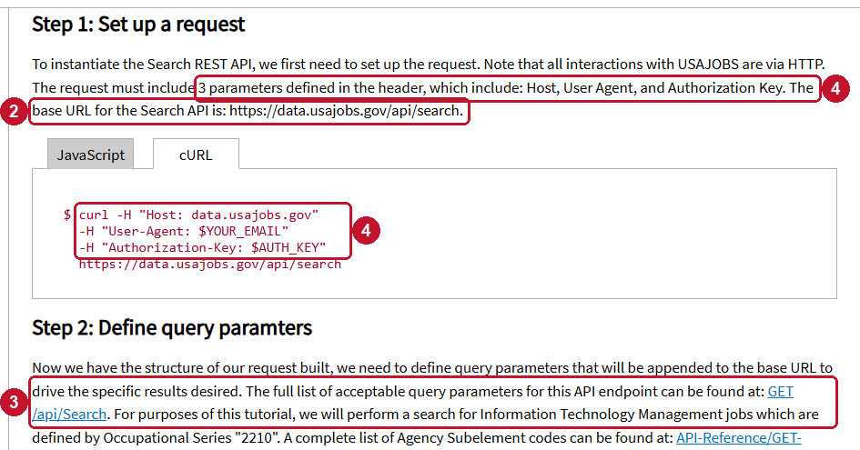

USAJOBS Developer Site, Tutorials, Search Jobs (cURL tab). Screenshot taken Sep 21, 2026.

# What the USAJOBS Pages Say

**1.****Key.** Free. Requested with a [form](https://developer.usajobs.gov/apirequest/) and sent by email.

**2.****Base URL and path.** `https://data.usajobs.gov/api/search`

**3.****Query parameters.** `Keyword`, `LocationName`, `ResultsPerPage`, and many more, listed in the [GET /api/Search reference](https://developer.usajobs.gov/api-reference/get-api-search).

**4.****Where the key goes.** In **headers**, three of them: `Host` (data.usajobs.gov), `User-Agent` (your email), `Authorization-Key` (your key).

**5.****Limits.** "The number of results returned per request defaults to 25 but can be defined in your request up to 500 per request."

**What is different from FRED:** the key is not a query parameter. It is sent in a header, together with two other headers that identify the sender.

# A Request, Step by Step: USAJOBS

GEThttps://data.usajobs.gov/api/search?Keyword=Data Analyst&ResultsPerPage=500

Headers

Host: data.usajobs.gov

User-Agent: yourname@miamioh.edu

Authorization-Key: ••••from .Renviron

Your R session

httr2 builds and sends the request

data.usajobs.gov

reads the headers first, then searches

```
httr2::request("https://data.usajobs.gov/api/search") |>  httr2::req_url_query(Keyword = "Data Analyst", ResultsPerPage = 500) |>  httr2::req_headers(    Host = "data.usajobs.gov",    "User-Agent" = "yourname@miamioh.edu",    "Authorization-Key" = Sys.getenv("USAJOBS_API_KEY")  ) |>  httr2::req_perform() |>  httr2::resp_body_string() |>  jsonlite::fromJSON(flatten = TRUE)
```

224 postings, 74 columns (two shown)

| title | department |
| --- | --- |
| DATA ANALYST | General Services Administratio |
| Data Analyst | Department of State |
| Program Analyst (Data Analyst) | Department of Homeland Securit |
| Program Analyst (Data Analytic | Department of Homeland Securit |

**USAJOBS** is the federal government's job board. Its API does not take the key as a query parameter.

**The address and the question,** as before: keyword and how many results per page.

**Send the request** without headers.

**403.** The server refuses requests that do not identify the sender. The reply is an HTML page, not JSON.

**Headers.** Name and value pairs that travel with the request but are not part of the address. The key goes here, read from `.Renviron`.

**Send the request** with the headers. The address is unchanged.

**200.** The address is the same as in the failed request. Only the headers were added.

**Parse.** The table is two levels down: `reply$SearchResult$SearchResultItems`.

0 / 7

# Demo: Data Analyst Jobs on USAJOBS

**Question.** How many federal postings match "Data Analyst" right now, and what does the reply look like?

```
[1] "SearchResultCount"    "SearchResultCountAll"
[3] "SearchResultItems"    "UserArea"
```

```
[1] 224  74
```

```
[1] "MatchedObjectId"
[2] "RelevanceRank"
[3] "MatchedObjectDescriptor.PositionID"
[4] "MatchedObjectDescriptor.PositionURI"
[5] "MatchedObjectDescriptor.OrganizationName"
```

Today: **224** postings, **74** columns. The count changes daily; yours may differ from your neighbor's by tomorrow.

Two levels down. The reply is a list, `SearchResult` is a list inside it, and `SearchResultItems` inside that is the table.

flatten = TRUE. Each posting is itself nested JSON. `jsonlite::fromJSON(flatten = TRUE)` spreads the nested fields into ordinary columns and joins the names with dots. That is where the long names come from.

# From Nested JSON to a Data Frame

**Question.** The table has 74 columns with names like `MatchedObjectDescriptor.PositionTitle`. How do we get to five readable ones?

usajobs_df: 74 columns, four shown

| MatchedObjectId | MatchedObjectDescriptor. PositionTitle | MatchedObjectDescriptor. DepartmentName | MatchedObjectDescriptor. PositionLocationDisplay |
| --- | --- | --- | --- |
| 883905900 | DATA ANALYST | General Services Adm | Multiple Locations |
| 883911800 | Data Analyst | Department of State | Washington, District |
| 883741500 | Program Analyst (Dat | Department of Homela | Washington, District |
| 885259500 | Program Analyst (Dat | Department of Homela | Washington, District |
| 885121100 | Management and Progr | Department of the In | Boise, Idaho |

→

dplyr::select(new_name = old_name, ...)

jobs_small: the same five postings

| title | department | location |
| --- | --- | --- |
| DATA ANALYST | General Services Administration | Multiple Locations |
| Data Analyst | Department of State | Washington, District of Columbia |
| Program Analyst (Data Analyst) | Department of Homeland Security | Washington, District of Columbia |
| Program Analyst (Data Analytics) | Department of Homeland Security | Washington, District of Columbia |
| Management and Program Analyst (Da | Department of the Interior | Boise, Idaho |

```
jobs_small = usajobs_df |>  dplyr::select(    title = MatchedObjectDescriptor.PositionTitle,    department = MatchedObjectDescriptor.DepartmentName,    agency = MatchedObjectDescriptor.OrganizationName,    location = MatchedObjectDescriptor.PositionLocationDisplay,    closes = MatchedObjectDescriptor.ApplicationCloseDate  )
```

# Practice: Federal Data Analyst Jobs

<countdown-timer class="countdown" id="timer_defe5885" minutes="5" seconds="0" update-every="1" tabindex="0" style="top:0;right:0;--countdown-font-size:2em;"></countdown-timer>

.panel[Task

Two questions on `jobs_small`

**1.** How many federal postings match "Data Analyst" today?

**2.** Which three departments have the most of them?

Work in pairs, in `class08.Rmd`. Your request must run from a fresh knit, with the key coming from `.Renviron`.

Key not here yet?

Pair with someone whose key has arrived, or answer these with your FRED key instead:

**1.** How many daily observations does `IHLIDXUSOH` have since 2026-01-01?

**2.** On which three dates in 2026 was the index highest?

.panel[Answer

<details class="answer-gate" style="margin-top:4px;"><summary style="cursor:pointer; font-weight:700; color:#c3142d; font-size:16px;">Answer will be shown in class</summary>

**1.** **224** postings when these slides were built (`nrow(jobs_small)`). The reply also reports it: `usajobs_reply$SearchResult$SearchResultCountAll` is 224.  
**2.** Department of Veterans Affairs (49); Department of the Air Force (47); Department of Defense (33).

Question 2 is `dplyr::count(department, sort = TRUE)` and `head(3)`. FRED version: 254 observations since 2026-01-01; the three highest dates come from `dplyr::filter()`, `dplyr::arrange(dplyr::desc(value))`, `head(3)`.

</details>

.panel[Discussion

**This count will be different tomorrow.** Postings open and close every day, so the same code gives a new answer each time it runs. What should a report built on an API always state?

**ResultsPerPage stops at 500.** What would you do if 1,200 postings matched?

- Notes from the room:

# Documentation: OpenAI

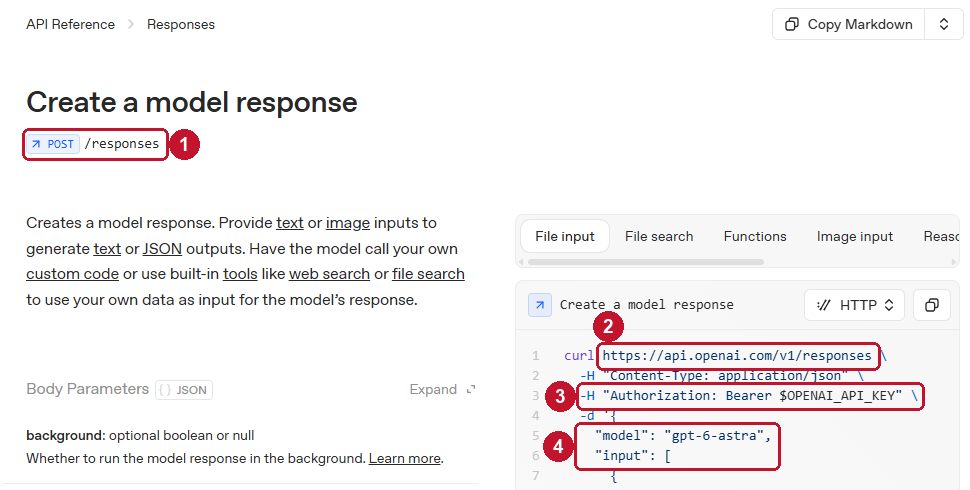

What this page tells us

1The method is **POST** and the path is `/responses`. The first three APIs today used GET.

2The **address**: `https://api.openai.com/v1/responses`. No query parameters.

3The key goes in a **header**: `Authorization: Bearer` followed by the key.

4The **body** is JSON with two fields we need: `model` and `input`. The page's example sends a file; `input` can also be plain text.

The full page: [Create a model response](https://developers.openai.com/api/reference/resources/responses/methods/create) in the OpenAI API reference. Screenshot taken Sep 21, 2026.

# A Request, Step by Step: OpenAI

POSThttps://api.openai.com/v1/responses

Headers

Authorization: Bearer ••••from .Renviron

Body (JSON)

{ "model": "gpt-5.6-luna", "input": "In one sentence, what is an API?" }

Your R session

httr2 builds and sends the request

api.openai.com

checks the key, runs the model on your input

```
httr2::request("https://api.openai.com/v1/responses") |>  httr2::req_headers(    Authorization = paste("Bearer", Sys.getenv("OPENAI_API_KEY"))  ) |>  httr2::req_body_json(list(    model = "gpt-5.6-luna",    input = "In one sentence, what is an API?"  )) |>  httr2::req_perform() |>  httr2::resp_body_json()
```

**OpenAI's API,** the one the Class 06 chat app sends its requests to.

**The address** has no query parameters. The input text can be long, so it is sent in the body instead.

**The header,** as with USAJOBS. OpenAI's documentation names it `Authorization` and wants the word Bearer before the key.

**The body** is data sent with the request, written as JSON. A request that carries a body is a **POST**; the first three were **GET**.

**Send.**

**200.** The reply is a status code and JSON, as with the other three APIs. The model's sentence is one string inside the JSON.

**Parse.** The reply is a nested list. Extract the text element.

0 / 6

# Calling OpenAI with httr2

**Question.** Part 1 showed that the chat app sends requests to OpenAI. Can we send one ourselves with the same httr2 pipeline?

```
reply = httr2::request("https://api.openai.com/v1/responses") |>  httr2::req_headers(    Authorization = paste("Bearer", Sys.getenv("OPENAI_API_KEY"))  ) |>  httr2::req_body_json(list(        # new: a body    model = "gpt-5.6-luna",    input = "In one sentence, what is an API?"  )) |>  httr2::req_perform() |>  httr2::resp_body_json() reply$output[[1]]$content[[1]]$text
```

```
An API (Application Programming Interface) is a set of rules
and tools that allows different software applications to
communicate with each other.
```

What is new. `httr2::req_body_json()` sends data **with** the request. A request with a body is a **POST**; everything before this slide was a **GET**. GET asks, POST sends.

The header. `Authorization: Bearer` followed by the key, as shown in Part 1. USAJOBS used a different header name; each API's documentation specifies its own.

How this relates to the app. Our `app.R` calls `ellmer::chat_openai(model = "gpt-5.6-luna")` and hands it to querychat. Packages like [ellmer](https://ellmer.tidyverse.org/) build and send this request for you.

The sentence on the left is the model's reply when these slides were built; yours will be worded differently. Reference: [OpenAI API, create a response](https://developers.openai.com/api/reference/resources/responses/methods/create).

# Our Class Git + GitHub Ritual

1 Knit

Click **Knit**. `class08.html` re-runs every chunk top to bottom and saves the page next to your markdown.

If the knit fails, a chunk depends on something you only ran in the Console. Fix the markdown, not the Console.

→

2 Commit

GitHub Desktop lists today's work: `markdowns/class08.Rmd` and `class08.html`. Nothing else.

Today you added two keys to `.Renviron`. If `.Renviron` is in the list, stop: uncheck it and run `usethis::use_git_ignore(".Renviron")`. Summary: `Add class 08 markdown on APIs`.

→

3 Push and verify

**Push origin**, then open the repo on GitHub and read `class08.Rmd` there.

Search the page for your key. You should find `Sys.getenv()` and nothing else.

**If it is not pushed, it is not done.** Your code contains the name of the key. The value stays on your PC.

# Recap

# Summary of Main Points

By now, you should be able to do the following:

- **Define** an API as a documented contract: you send a request the documentation describes, the server returns a status code and, when it says 200, data.
- **Construct** a request with `httr2::request()`, `httr2::req_url_query()`, and `httr2::req_headers()`, with every key read from `.Renviron` by `Sys.getenv()`.
- **Parse** the JSON reply with `jsonlite::fromJSON()`, find the table inside the list, and hand it to the dplyr verbs.

**Next class (Mon, Sep 28):** Web Scraping I, for the pages that have no API.

# Before You Go

[interactive chart not shown]

# 📝 Review and Clarification 📝

1. **Class Notes**: Take some time to revisit your class notes for key insights/concepts.

2. **Zoom Recording**: The recording of today's class will be made available on Canvas approximately 3-4 hours after the session ends.

3. **AI Recaps:** make your own with Gemini's NotebookLM, as I did for Class 01 (see the right).

4. **Questions**: Do not let confusion pile up.

Make your own recap in NotebookLM

1. Go to notebooklm.google.com and sign in with your Miami Google account.
2. Add today's slide deck as a source: paste the deck's address from Canvas as a **Website** source.
3. Click **Audio Overview** for a podcast, or **Video Overview** for a narrated video. Both take a few minutes to generate.

What it looks like: the Class 01 [video](https://www.youtube.com/watch?v=sys7WBk0iew) and [podcast](https://drive.google.com/file/d/1lt6hqrMuW8JOy9ilvkT5NVlPABowj7SE/view). Treat them as a study aid, not a substitute for the slides: the AI summarizes what is on the page and can misstate details.

# 🎯 Assignments 🎯

No new graded assignment today

**Keep your keys private.** The FRED and USAJOBS keys are registered to your email. They live in `.Renviron`, never in a markdown, a commit, a screenshot, or a chat message.

**Before you leave:** knit, then commit and push `markdowns/class08.Rmd` and `class08.html`. If it is not pushed, it is not done.

Ungraded Practice Questions

**1. Cincinnati (Appendix A1 and A2).** Which five `sna_neighborhood` values have the most records among the 1,000 most recent?

**2. FRED.** Get `IHLIDXUSOH` and `IHLIDXUS` since 2026-01-01. On how many days was Ohio's index above the national one?

**3. USAJOBS.** Change the request so it returns "Data Analyst" postings in Ohio (the documentation's `LocationName` parameter). How many are there?

**4. USAJOBS.** What are the typical minimum and maximum pay for today's postings? The pay columns are nested one level deeper; see Appendix A3.

**5. OpenAI.** Send your own one-sentence question. Then change `input` to ask for the answer in Spanish.

**Answers**

1. cincy_recent |> dplyr::count(sna_neighborhood, sort = TRUE) |> head(5)  
2. Two requests that differ only in series_id; dplyr::inner_join() the two data frames by date, then dplyr::filter(value.x > value.y) |> nrow()  
3. httr2::req_url_query(Keyword = "Data Analyst", LocationName = "Ohio", ResultsPerPage = 500)  
4. Appendix A3  
5. Only the input string changes; the header and the rest of the body stay as they are.

# Appendices

# A1: Cincinnati Example in httr2

**Question.** How many traffic crashes has Cincinnati recorded since August 1, 2026?

Two ways to answer. Download every record and count rows in R, or ask the server to count and download one number. The table has 433,160 rows today.

What is one row? One person involved in a crash. Rows from the same crash share an `instanceid`, so counting crashes means counting **distinct** `instanceid` values, with a condition on `crashdate`.

```
cincy_url = "https://data.cincinnati-oh.gov/resource/rvmt-pkmq.json" httr2::request(cincy_url) |>  httr2::req_url_query(    "$select" = "count(*) as records, count(distinct instanceid) as crashes",    "$where" = "crashdate >= '2026-08-01'"  ) |>  httr2::req_perform() |>  httr2::resp_body_string() |>  jsonlite::fromJSON()
```

```
  records crashes
1    1801     865
```

Is the number reasonable? The newest record is dated Aug 24, so the request covers 24 days: about 36 crashes a day, from 1,801 records. The same request for all of 2025 returns 14,941 crashes, about 41 a day. Both values are text, like every column from this server.

# A2: Practice: Build the URL

<countdown-timer class="countdown" id="timer_b6bc5fee" minutes="5" seconds="0" update-every="1" tabindex="0" style="top:0;right:0;--countdown-font-size:2em;"></countdown-timer>

.panel[Task

$limit $wherecrashdate >= $order $selectcount(*)

Open in a new tab

1. Pick any date in August 2026. How many crash records since that date? Let the **server** count.

2. Download the 1,000 most recent records. Which `crashseverity` is most common? Let **R** count.

**Why the quotes?** On this server the `$` is part of each parameter's name, and an R argument name cannot start with `$` unless it is quoted. FRED and USAJOBS use plain names, so no quotes are needed there. Tick boxes to build the request, open it in a browser tab to read the raw reply, then run the R version in `class08.Rmd`. The newest record in this table is dated 2026-08-24.

.panel[Answer

<details class="answer-gate" style="margin-top:4px;"><summary style="cursor:pointer; font-weight:700; color:#c3142d; font-size:16px;">Answer will be shown in class</summary>

**1.** Since 2026-08-01: **1,801** records (your date gives a different count), which come from 865 crashes. The reply is one row, and the number is text: `"1801"`.  
**2.** Of the 1,000 most recent: 5 - PROPERTY DAMAGE ONLY (747); 3 - MINOR INJURY SUSPECTED (132); 4 - INJURY POSSIBLE (102).

Question 1 is `"$select" = "count(*)"` plus `"$where"`. Question 2 is `"$limit" = 1000` plus `"$order" = "crashdate DESC"`, then `dplyr::count(crashseverity, sort = TRUE)` on the data frame. The full code is in this slide's notes.

</details>

.panel[Discussion

**Where was the counting done?** In question 1 the server counted and sent one number. In question 2 the server sent 1,000 rows and R counted. When is each approach appropriate?

**5 of the 1,000 "most recent" records have no date.** This server sorts missing values first when the order is descending. How would you have noticed?

**Every column is text,** including `age` and the count itself. What has to happen before `mean(age)`?

- Notes from the room:

# A3: Practice with USAJOBS Pay and Remotive

USAJOBS: typical pay

The column `MatchedObjectDescriptor.PositionRemuneration` is a **list column**: each cell holds a small data frame with `MinimumRange`, `MaximumRange`, and `RateIntervalCode` ("PA" means per year).

```
usajobs_df |>  dplyr::select(    title = MatchedObjectDescriptor.PositionTitle,    pay = MatchedObjectDescriptor.PositionRemuneration  ) |>  tidyr::unnest(pay) |>  dplyr::filter(RateIntervalCode == "PA") |>  dplyr::summarize(    min = median(as.numeric(MinimumRange)),    max = median(as.numeric(MaximumRange))  )
```

When these slides were built: median minimum $87,362, median maximum $117,525, across 223 per-year pay ranges.

Remotive: remote jobs, no key

**1.** Open remotive.com/api/remote-jobs?category=data&limit=25 in a browser tab. Read the **legal notice** at the top of the reply: it states what you may do with the data and asks you to credit Remotive and link back.

**2.** Write the same request with `httr2`. The table is the `jobs` element (13 columns when these slides were built).

**3.** The documented parameters are `category`, `company_name`, `search`, and `limit` ([Remotive API documentation](https://github.com/remotive-com/remote-jobs-api)). Use `search` to find postings that mention SQL.

**4.** Which `candidate_required_location` values are most common?

Job data on this slide's exercise comes from [Remotive](https://remotive.com). Its documentation advises at most four requests a day and blocks more than two a minute, so ask once, save the data frame, and work from the saved copy.

# A4: Reading

Suggested

[**Get started with httr2**](https://httr2.r-lib.org/articles/httr2.html)

The package's own introduction: create a request, modify it, perform it, read the response. Today's pipeline, with more options.

Skim if curious

[**httr2: Wrapping APIs**](https://httr2.r-lib.org/articles/wrapping-apis.html)

How R packages such as ellmer are built on top of requests like today's, including a section on keeping secrets out of code.

Skim if curious

[**FRED API documentation**](https://fred.stlouisfed.org/docs/api/fred/)

A well organized example of API documentation: every path, every parameter, an example request and reply for each.

Skim if curious

[**Socrata API endpoints and versions**](https://dev.socrata.com/docs/endpoints.html)

Explains the two versions seen on the Cincinnati portal: the older one we used (no key) and version 3, which requires authentication.